# Lab_Tree

## *Fitting Regression Trees*

Now we perform some quantitative analysis on the Boston data set. We begin by separating the test and the training group and fit the tree to the training data. A little bit about the dataset can be found [here](https://www.cs.toronto.edu/~delve/data/boston/bostonDetail.html)

1. **crim** - per capita crime rate by town
2. **zn** - proportion of residential land zoned for lots over 25,000 sq.ft.
3. **indus** - proportion of non-retail business acres per town.
4. **chas** - Charles River dummy variable (1 if tract bounds river; 0 otherwise)
5. **nox**- nitric oxides concentration (parts per 10 million)
6. **rm** - average number of rooms per dwelling
7. **age** - proportion of owner-occupied units built prior to 1940
8. **dis** - weighted distances to five Boston employment centres
9. **rad** - index of accessibility to radial highways
10. **tax** - full-value property-tax rate per $10,000
11. **ptratio**- pupil-teacher ratio by town
12. **b** - 1000(Bk - 0.63)^2 where Bk is the proportion of blacks by town
13. **lstat**- % lower status of the population
14. **medv**- Median value of owner-occupied homes in $1000’s

Basic information about the data set can be found in the code chunk below, to maintain good practices:

```r
dim(Boston)
```

```
## [1] 506  13
```

```r
summary(Boston)
```

```
##       crim                zn             indus            chas
##  Min.   : 0.00632   Min.   :  0.00   Min.   : 0.46   Min.   :0.00000
##  1st Qu.: 0.08205   1st Qu.:  0.00   1st Qu.: 5.19   1st Qu.:0.00000
##  Median : 0.25651   Median :  0.00   Median : 9.69   Median :0.00000
##  Mean   : 3.61352   Mean   : 11.36   Mean   :11.14   Mean   :0.06917
##  3rd Qu.: 3.67708   3rd Qu.: 12.50   3rd Qu.:18.10   3rd Qu.:0.00000
##  Max.   :88.97620   Max.   :100.00   Max.   :27.74   Max.   :1.00000
##       nox               rm             age              dis
##  Min.   :0.3850   Min.   :3.561   Min.   :  2.90   Min.   : 1.130
##  1st Qu.:0.4490   1st Qu.:5.886   1st Qu.: 45.02   1st Qu.: 2.100
##  Median :0.5380   Median :6.208   Median : 77.50   Median : 3.207
##  Mean   :0.5547   Mean   :6.285   Mean   : 68.57   Mean   : 3.795
##  3rd Qu.:0.6240   3rd Qu.:6.623   3rd Qu.: 94.08   3rd Qu.: 5.188
##  Max.   :0.8710   Max.   :8.780   Max.   :100.00   Max.   :12.127
##       rad              tax           ptratio          lstat
##  Min.   : 1.000   Min.   :187.0   Min.   :12.60   Min.   : 1.73
##  1st Qu.: 4.000   1st Qu.:279.0   1st Qu.:17.40   1st Qu.: 6.95
##  Median : 5.000   Median :330.0   Median :19.05   Median :11.36
##  Mean   : 9.549   Mean   :408.2   Mean   :18.46   Mean   :12.65
##  3rd Qu.:24.000   3rd Qu.:666.0   3rd Qu.:20.20   3rd Qu.:16.95
##  Max.   :24.000   Max.   :711.0   Max.   :22.00   Max.   :37.97
##       medv
##  Min.   : 5.00
##  1st Qu.:17.02
##  Median :21.20
##  Mean   :22.53
##  3rd Qu.:25.00
##  Max.   :50.00
```

Fitting the regression, we can see:

```r
# Setting the seed in order to make the results reproducible
set.seed(1)

# Separating the train and test set
train <- sample(1:nrow(Boston), nrow(Boston)/2)

# Building the model
tree.boston <- tree(medv ~., Boston, subset = train)

#Summary of the model
summary(tree.boston)
```

```
##
## Regression tree:
## tree(formula = medv ~ ., data = Boston, subset = train)
## Variables actually used in tree construction:
## [1] "rm"    "lstat" "crim"  "age"
## Number of terminal nodes:  7
## Residual mean deviance:  10.38 = 2555 / 246
## Distribution of residuals:
##     Min.  1st Qu.   Median     Mean  3rd Qu.     Max.
## -10.1800  -1.7770  -0.1775   0.0000   1.9230  16.5800
```

The only variables used to build the model were rm, lstat, crim and age, only 4 of the 12 predictor variables. Plotting the tree to get a more visual feeling:

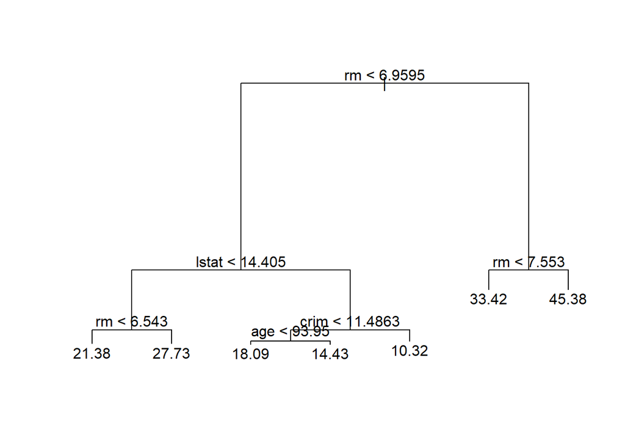

```r
plot(tree.boston)
text(tree.boston, pretty = 0)
```

We can infer from the tree, that houses with **rm** > 7.553 are more valuable and the model predicts a mean of $45.38 for houses that has more than 7-8 rooms.

Now we perform cross-validation. We could do this step right from the beggining, of course:

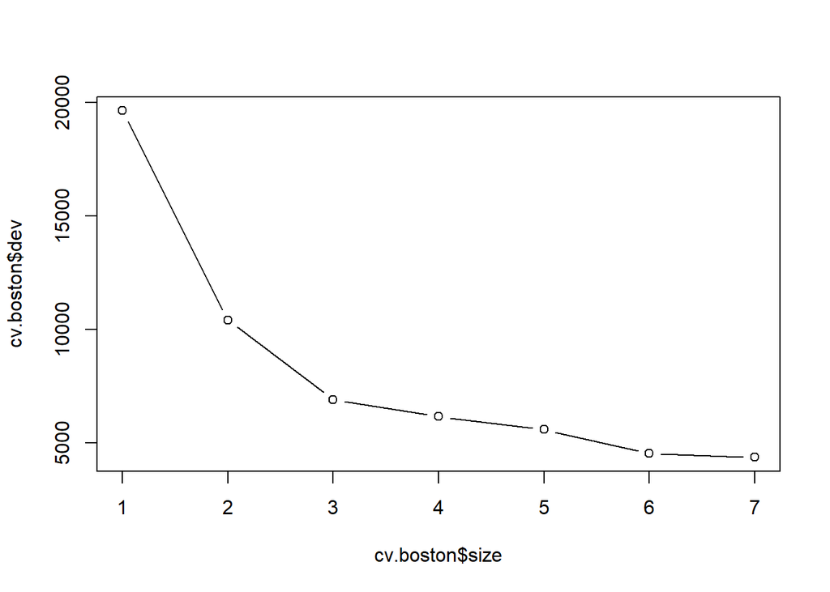

```r
# Remember that tree.boston is with the training subset
cv.boston <- cv.tree(tree.boston)

# Plotting the results
plot(cv.boston$size, cv.boston$dev, type = "b")
```

So the tree with 7 nodes can be selected but arguably the tree with 3 nodes could be selected as it looks like an elbow. We can prune the tree using the following:

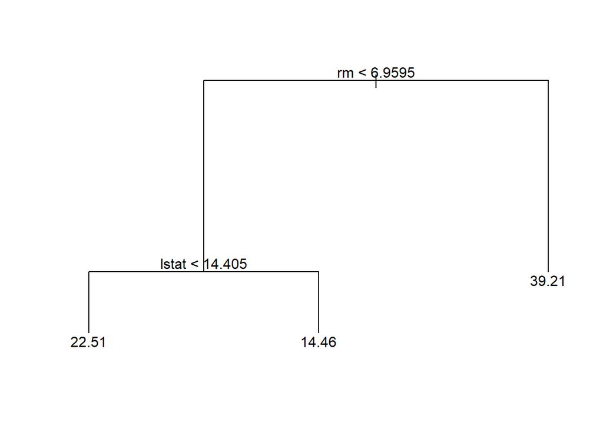

```r
prune.boston <- prune.tree(tree.boston, best = 3)
plot(prune.boston)
text(prune.boston, pretty = 0)
```

Keeping up with the cross-validation results, the unpruned tree should make the best predictions on the test set.

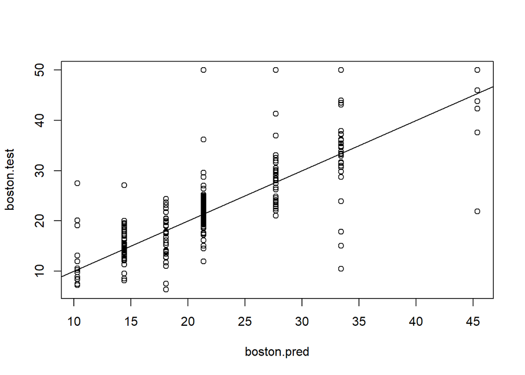

```r
boston.pred <- predict(tree.boston, newdata = Boston[-train,])
boston.test <- Boston[-train, "medv"]
plot(boston.pred, boston.test)
abline(0,1)
```

```r
mean((boston.pred - boston.test)^2)
```

```
## [1] 35.28688
```

The model is doing fine, and the graph looks like an stairway. The MSE is 35.29 and the RMSE is 5.941, indicating that the model leads to test predictions on average within approximately 5.941 of the true median home value for this data set. PRETTY GOOD!

## Bagging and Random Forests (RFs)

Now we begin to apply some advanced methods into our data!

Remembering that bagging is a special case of random forest where m = p. We can perform the bagging method using mtry = 12.

```r
library(randomForest)
set.seed(1)
bag.boston <- randomForest(medv ~., data = Boston, subset = train, mtry = 12, importance = TRUE)
```

> The argument mtry = 12 indicates that all 12 predictors should be considered for each split of the tree, which is actually bagging.

Let’s see how well the bagging model performs on the data:

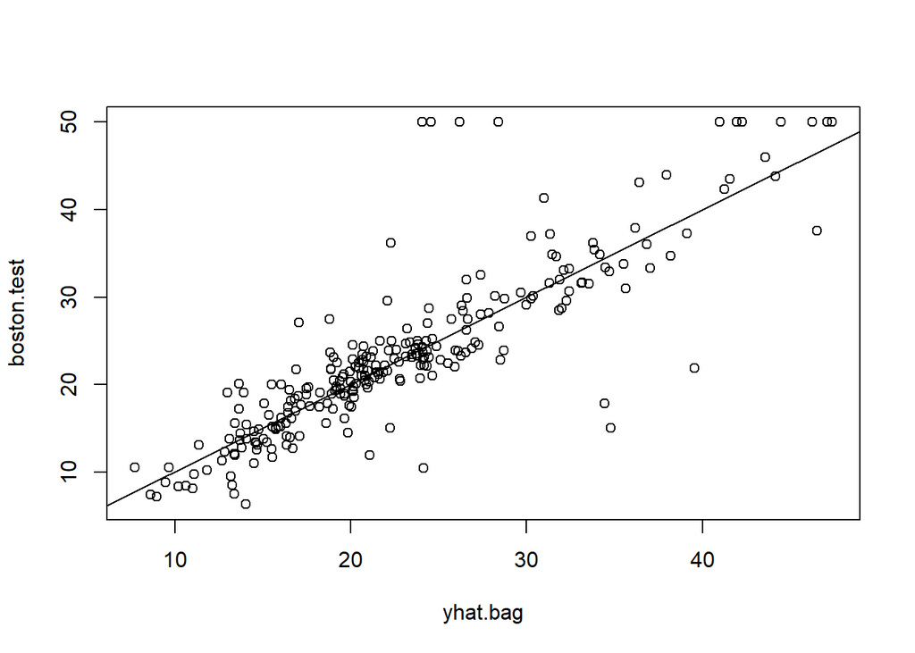

```r
yhat.bag <- predict(bag.boston, newdata = Boston[-train,])
plot(yhat.bag, boston.test)
abline(0,1)
```

Printing out the MSE of the Random Forest model above:

```r
mean((yhat.bag - boston.test)^2)
```

```
## [1] 23.41916
```

We can also specify the number of tree and compare:

```r
#notice that it is mtry = 12 so it is still bagging

bag.boston <- randomForest(medv~., data = Boston, subset = train,
                           mtry = 12, ntree = 25)
yhat.bag <- predict(bag.boston, newdata = Boston[-train,])
```

Evaluating the RF model (which is a bagging model as mtry = 12) and using ntree = 25:

```r
mean((yhat.bag - boston.test)^2)
```

```
## [1] 25.75055
```

So now we have 25.750, and that is a little higher than the defalt that before. Now let’s try using mtry with a value less than the total variables (mtry = 6).

```r
set.seed(1)
rf.boston <- randomForest(medv ~., data = Boston, subset = train, mtry = 6, importance = TRUE)
yhat.rf <- predict(rf.boston, newdata = Boston[-train,])
```

Evaluating the RF model with mtry = 6 we get a MSE of….

```r
mean((yhat.rf - boston.test)^2)
```

```
## [1] 20.06644
```

20! That’s even better. Let’s plot it and compare it with the plot before:

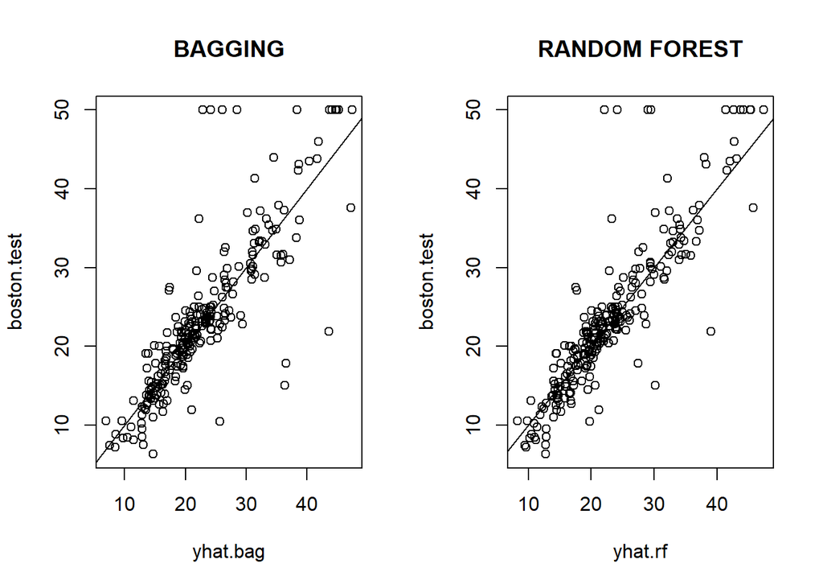

```r
par(mfrow = c(1,2))
plot(yhat.bag, boston.test, main = "BAGGING")
abline(0,1)
plot(yhat.rf, boston.test, main = "RANDOM FOREST")
abline(0,1)
```

We can also plot the variable importance to estimate the response variable using the function `varImpPlot()`:

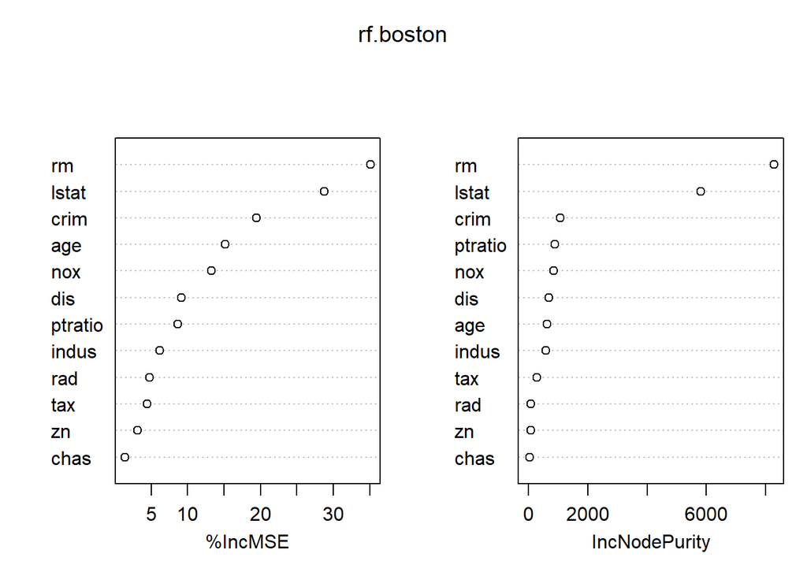

```r
varImpPlot(rf.boston)
```

> The results indicate that across all of the trees considered in the random forest, the wealth of the community (lstat) and the house size (rm) are by far the two most important variables.

## Boosting

The authors use the gbm package `gbm()` function to fit boosted regression trees to the Boston data set. We use the option for the argument `distribution = "gaussian"` since it is a regression problem but if it were a classification problem we would use the argument “`bernoulli"` . The argument `n.trees` limits the quantity of trees and the `interaction.depth` limits the depth of each tree.

```r
library(gbm)
set.seed(1)

boost.boston <- gbm(medv~., data = Boston[train,], distribution = "gaussian", n.trees = 5000, interaction.depth = 4)
```

We can use the `summary()` function to produce a relative influence plot that also outputs the relative influence statistics of each variable accompanied by a plot:

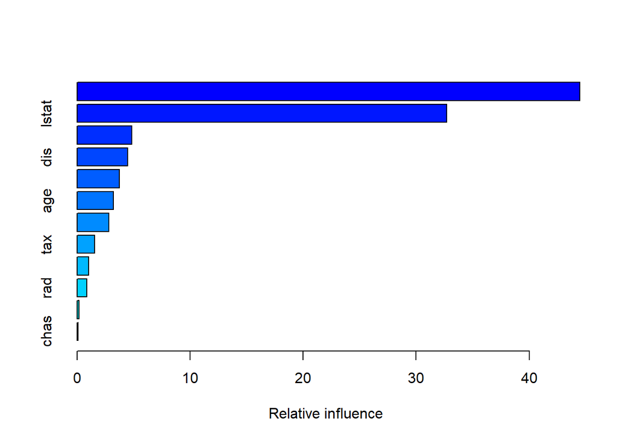

```
##             var     rel.inf
## rm           rm 44.48249588
## lstat     lstat 32.70281223
## crim       crim  4.85109954
## dis         dis  4.48693083
## nox         nox  3.75222394
## age         age  3.19769210
## ptratio ptratio  2.81354826
## tax         tax  1.54417603
## indus     indus  1.03384666
## rad         rad  0.87625748
## zn           zn  0.16220479
## chas       chas  0.09671228
```

```r
summary(boost.boston)
```

We see that rm and lstat are the most important variables. We can produce the partial depence plots for these two variables, for example:

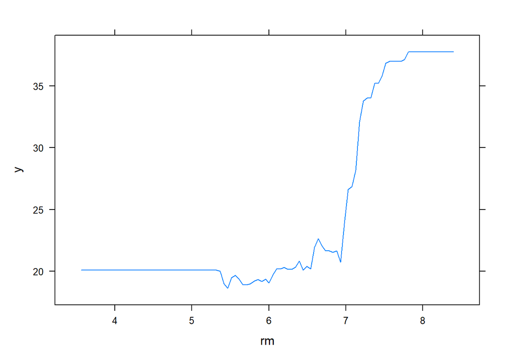

```r
par(mfrow = c(1,2))
plot(boost.boston, i = "rm")
```

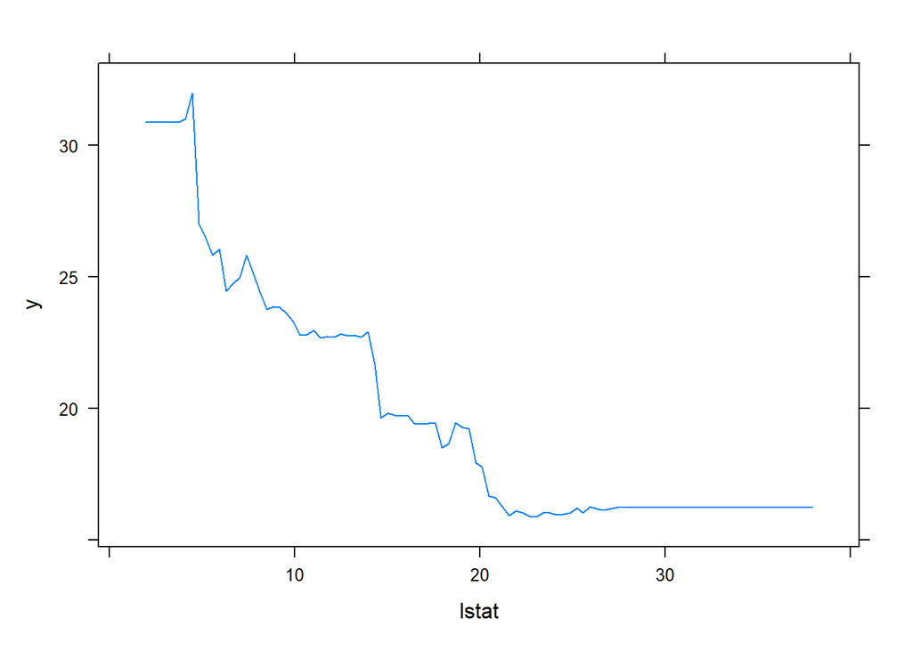

```r
plot(boost.boston, i = "lstat")
```

In this case the response variable y increases as rm increases and decreases as lstat increases. This makes total sense when we see what variable relates to the median house prices.

We now use the boosted model to predict the test group:

```r
yhat.boost <- predict(boost.boston, newdata = Boston[-train,], n.trees = 5000)
```

Evaluating the MSE of the model relative to the test group:

```r
mean((yhat.boost - boston.test)^2)
```

```
## [1] 18.39057
```

```r
boost.boston <- gbm(medv ~., data = Boston[train,], distribution = "gaussian", n.trees = 5000, interaction.depth = 4, shrinkage = 0.2, verbose = F)

yhat.boost <- predict(boost.boston, newdata = Boston[-train,], n.trees = 5000)

mean((yhat.boost - boston.test)^2)
```

```
## [1] 16.54778
```

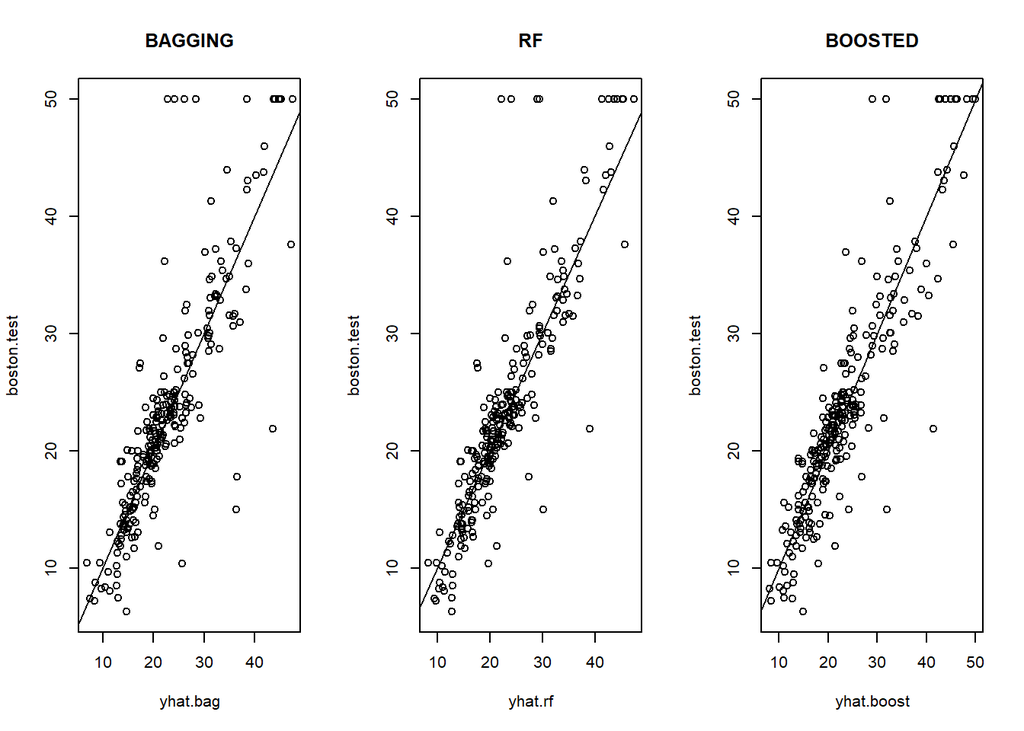

```r
par(mfrow = c(1,3))
plot(yhat.bag, boston.test, main = "BAGGING")
abline(0,1)

plot(yhat.rf,boston.test, main = "RF")
abline(0,1)

plot(yhat.boost, boston.test, main = "BOOSTED")
abline(0,1)
```

## Bayesian Additive Regression Trees

Now testing Bayesian Additive Regression Trees:

```r
library(BART)
x <- Boston[, 1:12]
y <- Boston[, "medv"]

xtrain <- x[train,]
ytrain <- y[train]

xtest <- x[-train,]
ytest <- y[-train]

set.seed(1)
bartfit <- gbart(xtrain, ytrain, x.test = xtest)
```

[output not shown]

```r
yhat.bart <- bartfit$yhat.test.mean
mean((ytest - yhat.bart)^2)
```

```
## [1] 15.94718
```

Let’s plot all against each other:

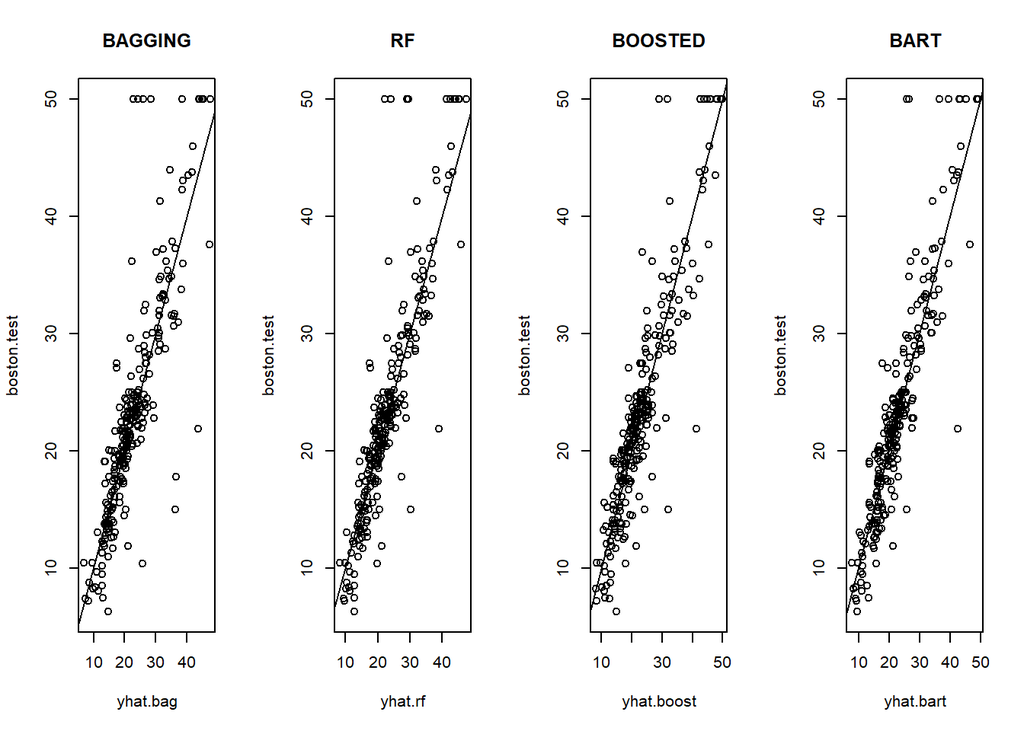

```r
par(mfrow = c(1,4))

plot(yhat.bag, boston.test, main = "BAGGING")
abline(0,1)

plot(yhat.rf,boston.test, main = "RF")
abline(0,1)

plot(yhat.boost, boston.test, main = "BOOSTED")
abline(0,1)

plot(yhat.bart, boston.test, main = "BART")
abline(0,1)
```

FINISH!